# PA1_Template.RMD

## Setting the directory

- Set directory

```r
 setwd("C:/Users/Kristen/Documents/R/HWRR2")

 getwd()
```

```
## [1] "C:/Users/Kristen/Documents/R/HWRR2"
```

## Loading the data

- Load the data

```r
activity=read.csv("activity.csv")
```

- Pull up plotting package

```r
library(ggplot2)
library(dplyr)
library(plyr)
```

- Create weeekday variable and format date time

```r
activity$day <- weekdays(as.Date(activity$date))
activity$DateTime<- as.POSIXct(activity$date, format="%Y-%m-%d")
```

## Q1: What is mean total number of steps taken per day?

- Calculate the total number of steps taken per day

```r
sumsteps <- aggregate(activity$steps ~ activity$date, FUN=sum, )
colnames(sumsteps)<- c("Date", "Steps")
```

- Make a histogram of the total number of steps taken each day

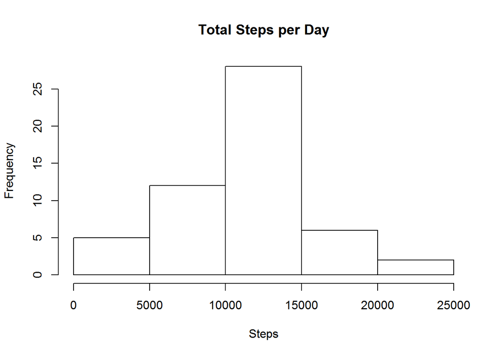

```r
hist(sumsteps$Steps, breaks=5, xlab="Steps", main = "Total Steps per Day")
```

- Calculate and report the **mean** and **median** total number of steps taken per day

```r
as.integer(mean(sumsteps$Steps))
```

```
## [1] 10766
```

```r
as.integer(median(sumsteps$Steps))
```

```
## [1] 10765
```

- The **mean** total number of steps taken per day is 10766
- The **median** total number of steps taken per day is 10765

## Q2 What is the average daily activity pattern?

- Make a time series plot (i.e. type = “l”) of the 5-minute interval (x-axis) and the average number of steps taken, averaged across all days (y-axis)
- Creating dataset with missing values removed

```r
nomiss <- activity[!is.na(activity$steps),]
```

- Create average number of steps per interval

```r
intervaldata <- ddply(nomiss, .(interval), summarize, Avg = mean(steps))
```

- Create line plot of average number of steps per interval

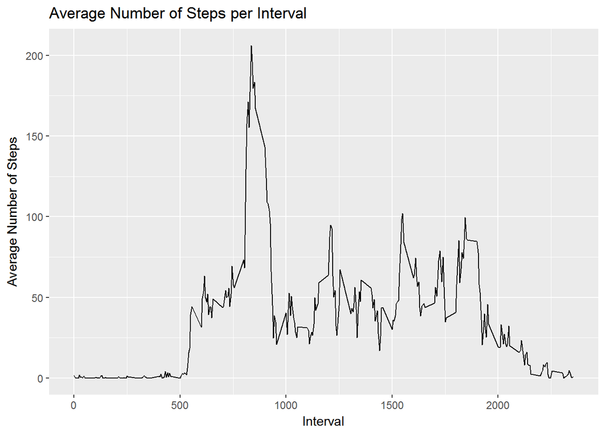

```r
p <- ggplot(intervaldata, aes(x=interval, y=Avg), xlab = "Interval", ylab="Average Number of Steps")
p + geom_line()+xlab("Interval")+ylab("Average Number of Steps")+ggtitle("Average Number of Steps per Interval")
```

*Which 5-minute interval, on average across all the days in the dataset, contains the maximum number of steps?

*Calculate maximum steps by interval

```r
maximumSteps <- max(intervaldata$Avg)
```

*Which interval contains the maximum average number of steps

```r
intervaldata[intervaldata$Avg==maximumSteps,1]
```

```
## [1] 835
```

- It is interval 835.

## Q3 Imputing missing values

- Calculate and report the total number of missing values in the dataset (i.e. the total number of rows with NAs)

```r
nrow(activity[is.na(activity$steps),])
```

```
## [1] 2304
```

- Total 2304 rows are missing.
- Devise a strategy for filling in all of the missing values in the dataset. The strategy does not need to be sophisticated. For example, you could use the mean/median for that day, or the mean for that 5-minute interval, etc.
- I used mean value for missing values
- Create the average number of steps per day / interval

```r
avgdata <- ddply(nomiss, .(interval, day), summarize, Avg = mean(steps))
```

- Create dataset with only NAs

```r
missingdata<- activity[is.na(activity$steps),]
```

- Merge NA data with average weekday interval

```r
mergedata<-merge(missingdata, avgdata, by=c("interval", "day"))
```

- Create a new dataset with missing data now filled in.

```r
mergedata2<- mergedata[,c(6,4,1,2,5)]
colnames(mergedata2)<- c("steps", "date", "interval", "day", "DateTime")
```

*Merge the missing averages and non-missing data

```r
FinalData <- rbind(nomiss, mergedata2)
```

- Make a histogram of the total number of steps taken each day and Calculate and report the mean and median total number of steps taken per day.

```r
sumsteps2 <- aggregate(FinalData$steps ~ FinalData$date, FUN=sum, )
colnames(sumsteps2)<- c("Date", "Steps")
```

*Mean of Steps with imputed missing data

```r
as.integer(mean(sumsteps2$Steps))
```

```
## [1] 10821
```

*Median of Steps with imputed missing data

```r
as.integer(median(sumsteps2$Steps))
```

```
## [1] 11015
```

*Creating the histogram of total steps per day - compare dataset with imputed data to data from first part of assigment to show impact

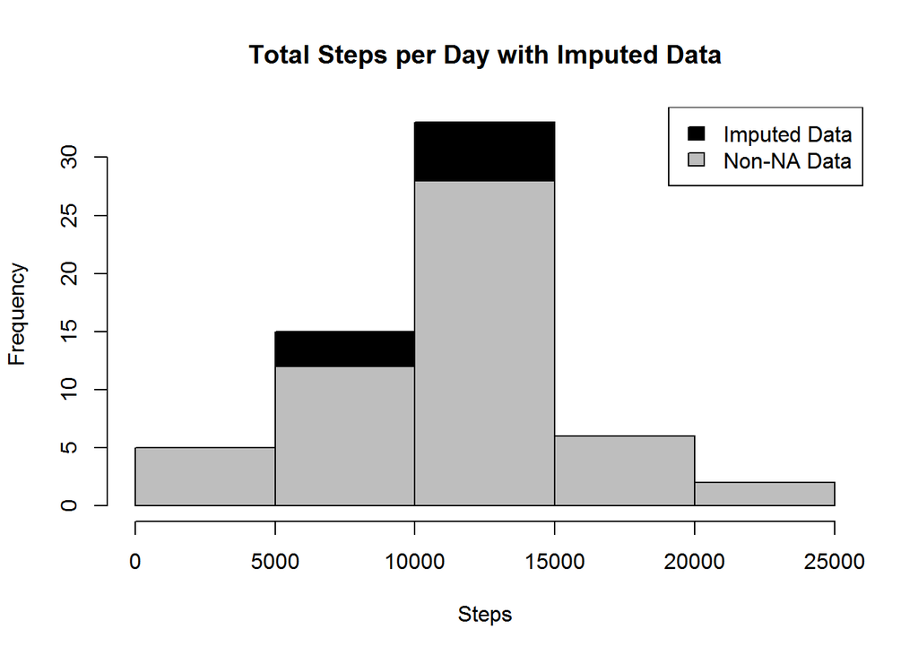

```r
hist(sumsteps2$Steps, breaks=5, xlab="Steps", main = "Total Steps per Day with Imputed Data", col="Black")
hist(sumsteps$Steps, breaks=5, xlab="Steps", main = "Total Steps per Day with Imputed data", col="Grey", add=T)
legend("topright", c("Imputed Data", "Non-NA Data"), fill=c("black", "grey") )
```

* Do these values differ from the estimates from the first part of the assignment? What is the impact of imputing missing data on the estimates of the total daily number of steps?

- The **mean** and **median** values are both greater after imputting data.

## Q4 Are there differences in activity patterns between weekdays and weekends?

- Create a new dichotomous variable to identify if the day is a weekday or a weekend.

```r
FinalData$DayType <- ifelse(FinalData$day %in% c("Saturday", "Sunday"), "Weekend", "Weekday")
```

```r
library(lattice)
```

*Summarize data by interval and weekend / weekday category

```r
intervaldata <- ddply(FinalData, .(interval, DayType), summarize, Avg = mean(steps))
```

*Plot data in a panel plot

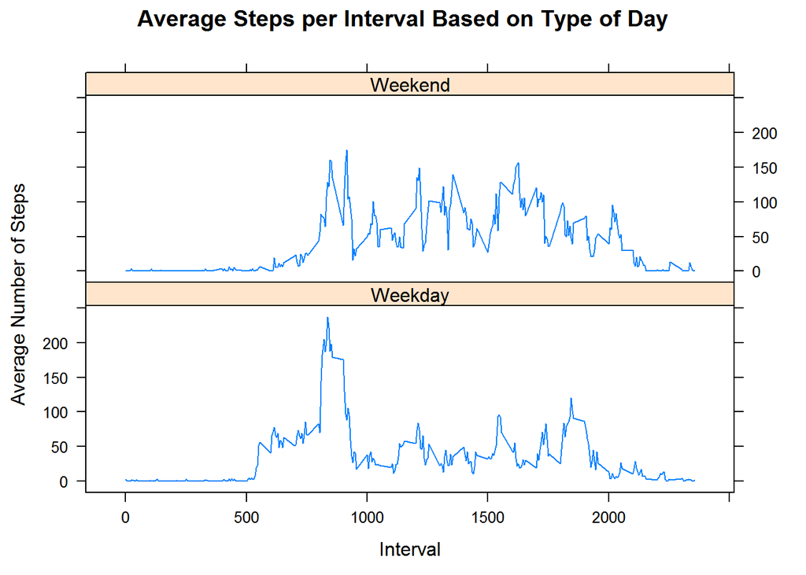

```r
xyplot(Avg~interval|DayType, data=intervaldata, type="l",  layout = c(1,2),
       main="Average Steps per Interval Based on Type of Day",
       ylab="Average Number of Steps", xlab="Interval")
```